# Comparing naive and dynamic SOC depth correction approaches, and testing DSM estimates of initial SOC

Francis Durnin-Vermette

2023/01/24

The purpose of this report is to

1. Give an overview of how depth measurements from field data can be corrected to the target depth for use in SOC model validation using a dynamic depth correction approach, and
2. Visualize the realism of initial SOC estimates for Canadian long-term experimental sites.

These estimates were obtained using a digital soil mapping (DSM) method because some sites do not have an initial SOC measurement, which is an important parameter in SOC modelling.

# 1 Assumptions

We assume: - Soil management has no effect on bulk density - When using the naive depth correction approach, we assume SOC levels are homogenous throughout the soil, but when using the dynamic depth correction approach, we do not assume homogeneity. - The initial year from the DSM estimates are either 1999, or the year of the first SOC measurement in that experiment; whichever is earlier (This assumption only affects visualizations, not SOC calculations).

# 2 Depth correction method

Many of these experiments did not sample SOC at depths 0-30cm. We corrected these values using two different algorithms: the naive method, and the dynamic method.

## 2.1 Naive

If we assume the the measured SOC is evenly distributed between 0 and 30cm (i.e. the soil is homogenous), we can correct the measured soil depth to 0-30cm using the following equation:

$$SOC_{30} = SOC_{measured} * \frac{30cm}{max_{depth} - min_{depth}}$$

## 2.2 Dynamic

However, it is not safe to assume that the soil has homogeneous SOC stocks because it is known that C content changes drastically at different depths. If we do not assume homogeneity, then we must take into account SOC at different depths during our depth corrections. In order to do this, we can use the initial C estimate (which is estimated for 0-30cm), and find the difference between this and the measured C (e.g. 0-20cm) in order to establish a constant 20-30cm C value for that experiment. The fact that this difference is constant is an assumption based on the premise that the SOC content at lower depths (e.g. 20-30cm) does not fluctuate as much as lower depths, and are also not as affected by treatment effects.

In order to correct for SOC following the dynamic method, I follow these steps:

- For each treatment, sum every SOC depth measurement less than or equal to 30cm deep. For instance, sum the measurements of 0-7.5cm and 7.5-15cm to calculate 0-15cm.
- Take the DSM initial C estimate from the same experiment (0-30cm), and find the difference in SOC between the first measured SOC (0-15cm) and the initial SOC (0-30cm), which represents SOC at 15-30cm.
- Sum the measured 0-15cm with the estimated 15-30cm SOC to arrive at an estimated 0-30cm SOC.
- The same value for 15-30cm will be used for the entire site/treatment, because the initial DSM estimate doesn’t change within the site/treatment, and neither does the first measured SOC point.

Other situations that need to be handled:

- If the measured SOC points have been measured at different depths, and it is possible to arrive at 0-30cm depth using multiple combinations of sampling depths, then we calculate the 0-30cm depth using all possible combinations, and get the average between all groupings.

# 3 Testing SOC depth correction method

One problem we run into with the data is that sometimes there are multiple ways to arrive at 0-30cm from the same site. For instance, some treatments in Lethbridge measure 0-7.5, 7.5-15, 15-30, and 0-15. In this case, there are two ways to arrive at 0-30: either 0-7.5 + 7.5-15 + 15-30, or just 0-15 + 15-30.

In order to handle this, I made a function `make_depth_groups` which makes a dataset with both groupings in order to arrive at 0-30cm. In the above example, this duplicates the 15-30cm measurements since they are used in both groupings.

In order to avoid duplicating data which could affect the statistical properties of simulations, we find the average SOC between possible depth groupings.

```r
site_data_depth_groups <- site_data_all %>%
    full_join(initialc_dsm, by=c("location_name")) %>%
    full_join(initialc_cmods, by="location_name") %>%
    select(Exp_ID, location_name, treatment_number,treatment_name, year_name, replication_number, soil_depth, soil_depth_min_cm, soil_depth_max_cm,
                 initial_soc_year,
                 initial_dataset = initial_soc_tha,
                 soc_tha) %>%
    filter(!is.na(soc_tha)) %>%
    # Get the mean for field_name, replication_number, and block
    group_by(Exp_ID, location_name, year_name, treatment_number, treatment_name, soil_depth_min_cm, soil_depth_max_cm, initial_soc_year) %>%
    summarise(across(initial_dataset:soc_tha, mean)) %>%
    group_by(Exp_ID, location_name, year_name, treatment_number, treatment_name) %>%
    group_split() %>%
    purrr::map(~make_depth_groups(.)) %>%
    bind_rows
```

Now we add different estimates of initial C. These come from the digital soil mapping (DSM) estimates and the CMods repository.

We assume that the DSM estimates are from the year 1999 or earlier, and if the first measures SOC event for that experiment is before 1999 we choose the first year before that measurement as the initial SOC estimate year.

```r
site_data_joined <- site_data_depth_groups %>%
    left_join(initialc_dsm, by=c("location_name")) %>%
    left_join(initialc_cmods, by="location_name") %>%
    select(Exp_ID, location_name, treatment_number,treatment_name, year_name, lowest_depth, soil_depth,
                 soil_depth_min_cm, soil_depth_max_cm, combination_group,
                 soc_tha, initial_dataset, initial_dsm, initial_cmods, initial_soc_year) %>%
    # Set the initial C to either be 1 year before the first year ever measured for that site, or 1999 (maximum start date).
    group_by(Exp_ID, location_name) %>%
    mutate(initial_soc_year_dsm = ifelse(min(year_name) < 2000, min(year_name)-1, 1999))
```

Now we sum each of the depths for each depth group in order to arrive at the total SOC for the lowest measured depth.

```r
site_data_summed <- site_data_joined %>%
    group_by(Exp_ID, location_name, year_name, treatment_number, treatment_name, initial_dataset, initial_dsm, initial_cmods, initial_soc_year, initial_soc_year_dsm, combination_group, lowest_depth) %>%
    summarise(soc_tha_lowest_depth = sum(soc_tha)) %>%
    # Get mean values for each combination group to remove duplicates
    group_by(Exp_ID, location_name, year_name, treatment_number, treatment_name, initial_dataset, initial_dsm, initial_cmods, initial_soc_year, initial_soc_year_dsm, lowest_depth) %>%
    summarise(across(c("soc_tha_lowest_depth"), mean))
```

[output not shown]

Now, in circumstances where 0-30cm is measured, we can just use this number. However, if less or more than 30cm is measured in total, then we need to perform correction.

In order to do this, we find the difference between the initial DSM estimate for the site/treatment, and find the difference between that and the first SOC measurements for that site_treatment. Then, we just add that difference to each measurement of SOC for the site/treatment.

```r
site_data_corrected <- site_data_summed %>%
    group_by(Exp_ID, location_name, treatment_number, treatment_name) %>%
    mutate(first_soc_treatment = first(soc_tha_lowest_depth),
                 soc_dsm_difference = initial_dsm - first_soc_treatment,
                 lowest_depth_difference = 30 - lowest_depth,
                 soc_30cm_dynamic = ifelse(lowest_depth_difference != 0,
                                                            soc_tha_lowest_depth + soc_dsm_difference,
                                                            soc_tha_lowest_depth)) %>%
    mutate(soc_30cm_naive = soc_tha_lowest_depth * (30/lowest_depth))
```

## 3.1 Lethbridge

```r
site_data_corrected %>%
    select(Exp_ID, location_name, treatment_name, year_name,
                 initial_dsm,
                 soc_30cm_naive, soc_30cm_dynamic
    ) %>%
    filter(location_name == "Lethbridge") %>%
    filter(!is.na(soc_30cm_naive)) %>%
    filter(treatment_name == "Fw-Wt I")
```

| treatment_number | Exp_ID | location_name | treatment_name | year_name | initial_dsm | soc_30cm_naive | soc_30cm_dynamic |
| --- | --- | --- | --- | --- | --- | --- | --- |
| 2 | 4 | Lethbridge | Fw-Wt I | 1954 | 91.5 | 89.075 | 89.075 |
| 2 | 4 | Lethbridge | Fw-Wt I | 1967 | 91.5 | 81.850 | 81.850 |
| 2 | 4 | Lethbridge | Fw-Wt I | 1974 | 91.5 | 76.050 | 76.050 |
| 2 | 4 | Lethbridge | Fw-Wt I | 1985 | 91.5 | 73.350 | 73.350 |
| 2 | 4 | Lethbridge | Fw-Wt I | 1992 | 91.5 | 101.500 | 101.500 |

For year = 1992:

SOC was measured at 0-7.5, 7.5-15, and 15-30cm for this year.

### 3.1.1 Naive

Treatment 0-30cm = **101.500**

### 3.1.2 Dynamic

There is no difference between the dynamic approach and the naive approach because 30cm was measured in total.

## 3.2 Ellerslie

```r
site_data_corrected %>%
    select(Exp_ID, location_name, treatment_name, year_name,
                 initial_dsm, soc_tha_lowest_depth,
                 soc_30cm_naive, soc_30cm_dynamic
    ) %>%
    filter(location_name == "Ellerslie") %>%
    filter(!is.na(soc_30cm_naive)) %>%
    filter(treatment_name == "F25NS")
```

| treatment_number | Exp_ID | location_name | treatment_name | year_name | initial_dsm | soc_tha_lowest_depth | soc_30cm_naive | soc_30cm_dynamic |
| --- | --- | --- | --- | --- | --- | --- | --- | --- |
| 7 | 1 | Ellerslie | F25NS | 1983 | 131.9 | 110.21 | 165.315 | 131.90 |
| 7 | 1 | Ellerslie | F25NS | 1995 | 131.9 | 126.40 | 189.600 | 148.09 |
| 7 | 1 | Ellerslie | F25NS | 2009 | 131.9 | 123.32 | 184.980 | 145.01 |

Let’s see if our new method of estimating SOC at 30cm works.

For year = 2009:

### 3.2.1 Naive

Treatment 0-20cm = 123.3200

Treatment 0-30cm = 123.3200 * (30/20) = **184.98**

### 3.2.2 Dynamic

Treatment 0-20cm = 123.3200

DSM Initial 0-30cm = 131.9

Treatment 0-20cm in first year = 110.21

Treatment 0-30cm = 123.3200 + 21.69 = **145.01**

# 4 Graphing

## 4.1 All sites

Looking at all the sites, we can see that the DSM initial estimates seem to generally agree well with measured SOC values.

Additionally, it appears that in many cases (e.g. Ellerslie) the dynamic SOC estimation method leads to SOC values that seem more realistic within the context of the DSM initial C estimates.

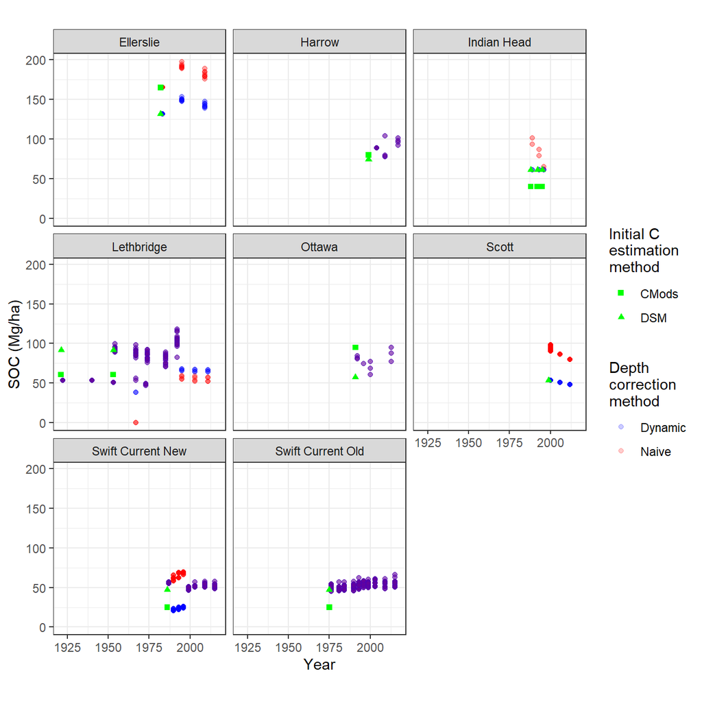

### 4.1.1 Ellerslie

The DSM estimates and dynamic depth correction approach have the effect of decreasing SOC values, and also reducing the rate of change of SOC values over time.

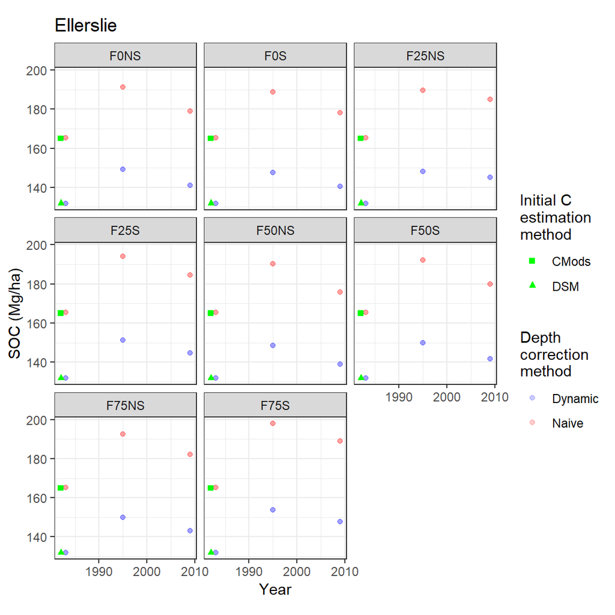

### 4.1.2 Harrow

Both estimates of initial C are realistic for Harrow. The DSM estimates are further away from the first measured value than the CMods initial estimates.

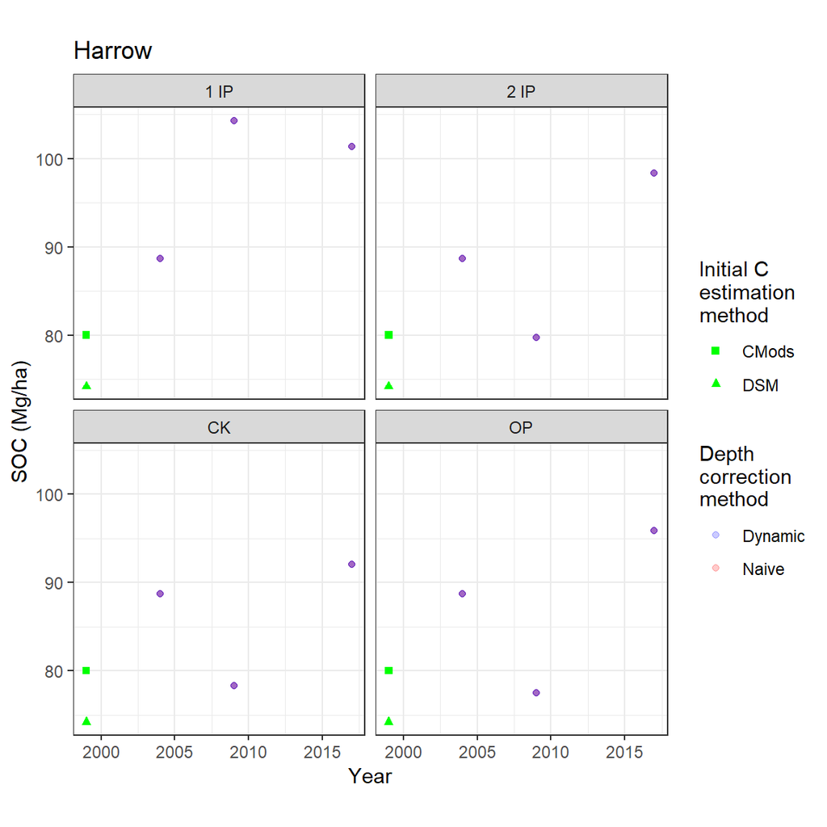

### 4.1.3 Indian Head

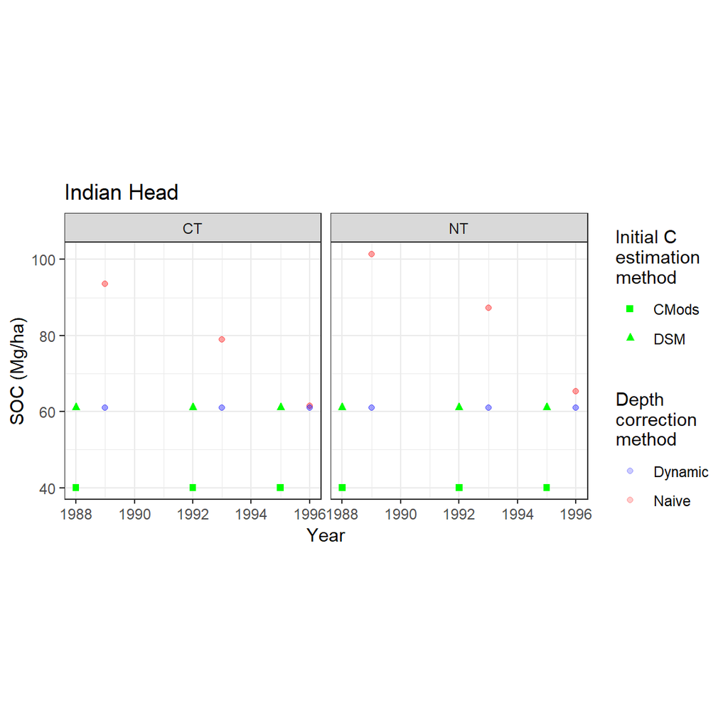

### 4.1.4 Lethbridge

The DSM values for Lethbridge work well with the measured values, and are an improvement over the CMods initial estimates.

There are some issues with the data for the fertilization experiment (Exp_ID = 5; treatments = N0P0, N0P20, N45P0, N45P20). There are some instances in the data where only 0-15cm is measured, and others where 0-30cm is measured.

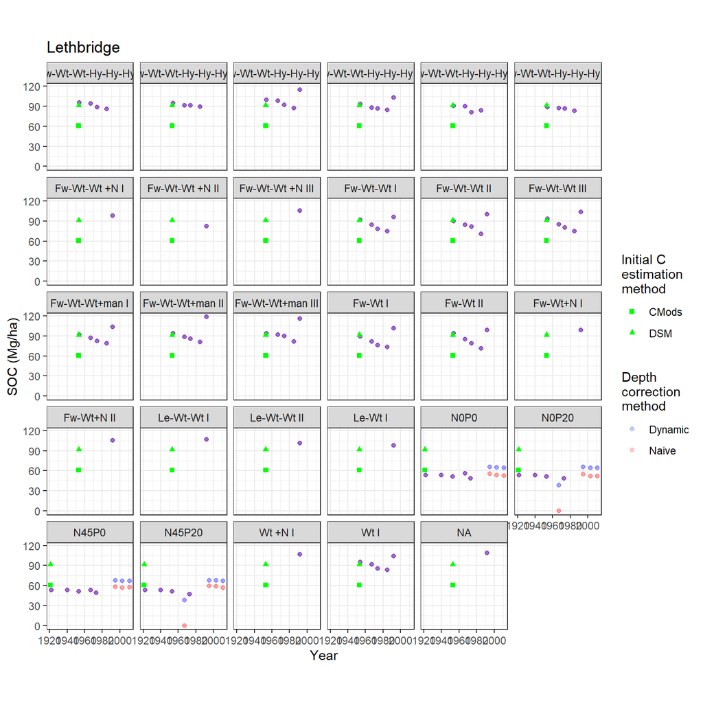

### 4.1.5 Ottawa

The DSM initial C estimate does not work as well for our Ottawa data - there are large 40-50% increases in SOC from the initial C to the first measured value.

The CMods initial estimates are a bit more realistic, because they show a sudden SOC decrease following the beginning of the experiment.

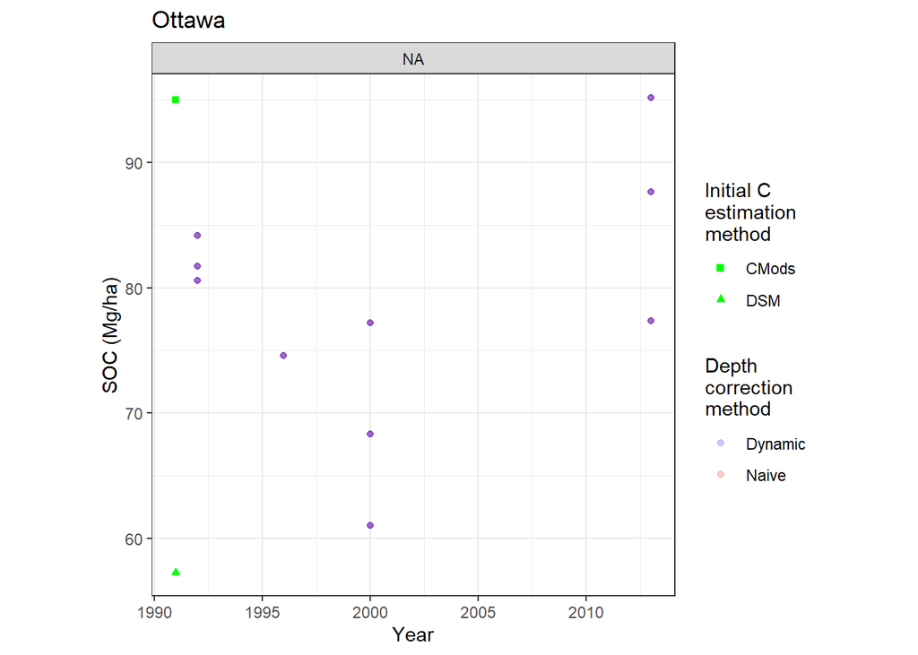

### 4.1.6 Scott

Using the DSM initial estimates along with the dynamic approach makes the data for Scott more realistic.

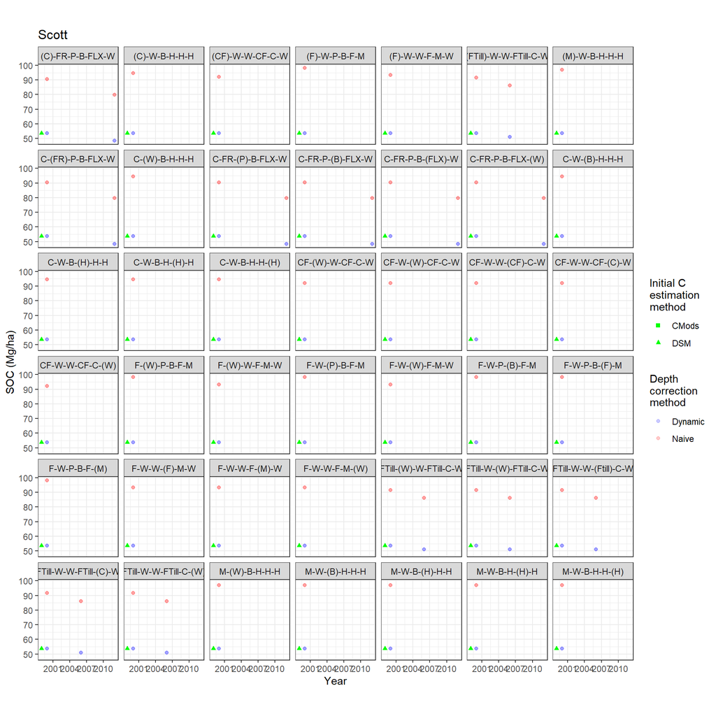

### 4.1.7 Swift Current New

The DSM initial C values work very well for the Swift Current New experiments, and they are large improvements over the CMods estimates.

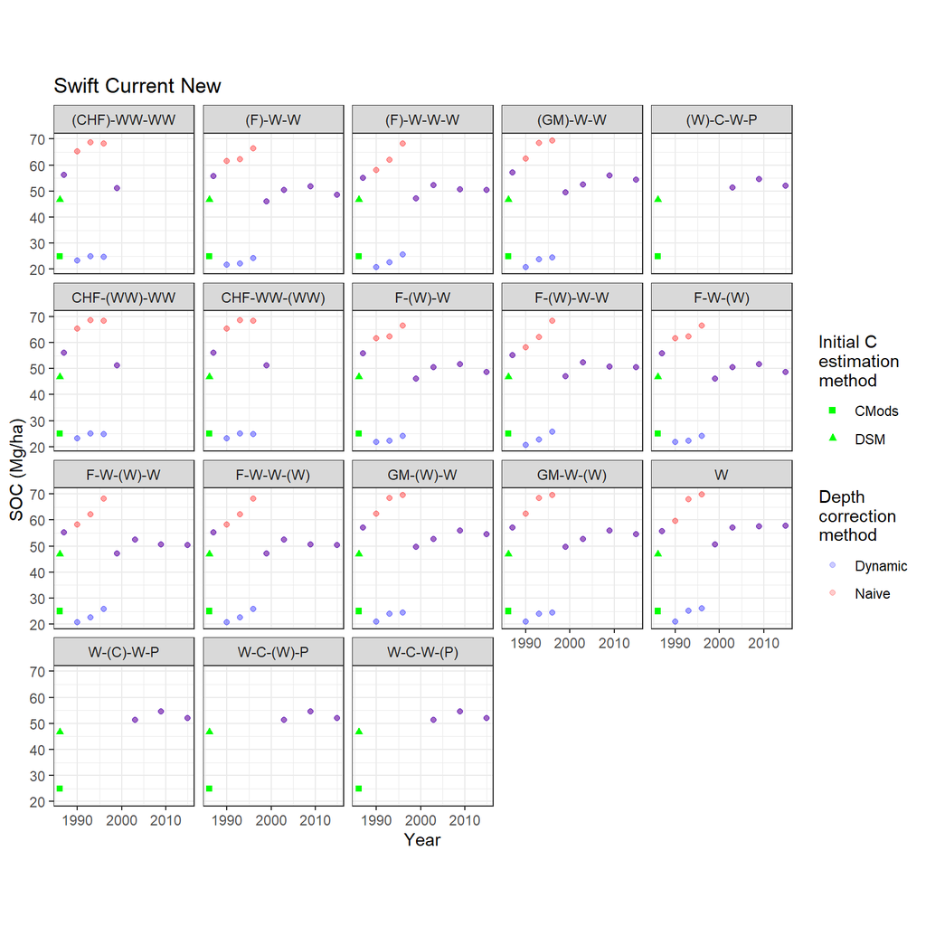

### 4.1.8 Swift Current Old

The DSM initial C estimates generally work well for Swift Current Old, and are also large improvements over the CMods estimates.

Using the dynamic method to correct SOC measurements is completely equivalent to using the naive approach.

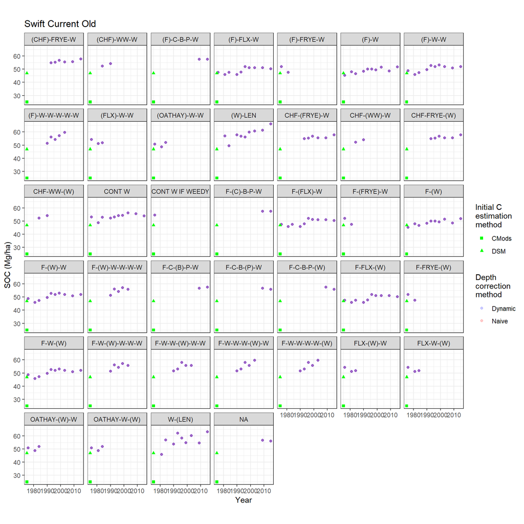